# hw02_gapminder

Liming Liu

2018-09-20

# Explore Gapminder and use dplyr

## Bring rectangular data in

```r
library(tidyverse)
library(gapminder)
```

## Smell test the data

#### 1.The type of gapminder

```r
typeof(gapminder)
```

```
## [1] "list"
```

#### 2. The class of gapminder

```r
class(gapminder)
```

```
## [1] "tbl_df"     "tbl"        "data.frame"
```

#### 3. How many rows and columns?

1704 rows,6 columns

```r
nrow(gapminder)
```

```
## [1] 1704
```

```r
ncol(gapminder)
```

```
## [1] 6
```

#### 4. Can you get these facts about “extent” or “size” in more than one way? Can you imagine different functions being useful in different contexts?

1. Use array()

```r
array(gapminder)
```

[output not shown]

2. Use dim()

```r
dim(gapminder)
```

```
## [1] 1704    6
```

3. Use dim_desc()

```r
dim_desc(gapminder)
```

```
## [1] "[1,704 x 6]"
```

4. Use dim.data.frame()

```r
dim.data.frame(gapminder)
```

```
## [1] 1704    6
```

#### 5. What data type is each variable?

```r
head(gapminder)
```

```
## # A tibble: 6 x 6
##   country     continent  year lifeExp      pop gdpPercap
##   <fct>       <fct>     <int>   <dbl>    <int>     <dbl>
## 1 Afghanistan Asia       1952    28.8  8425333      779.
## 2 Afghanistan Asia       1957    30.3  9240934      821.
## 3 Afghanistan Asia       1962    32.0 10267083      853.
## 4 Afghanistan Asia       1967    34.0 11537966      836.
## 5 Afghanistan Asia       1972    36.1 13079460      740.
## 6 Afghanistan Asia       1977    38.4 14880372      786.
```

From the results above, we can see that column “country”, “continent” are factor; column “year”, “pop” are integer; column “lifeExp”, “gdpPercap” are double

## Explore individual variables

Pick at least one categorical variable and at least one quantitative variable to explore.

select variables in “continent” and “pop” columns

```r
test_var <- select(gapminder, continent, pop)
```

#### 1. What are possible values (or range, whichever is appropriate) of each variable?

```r
summary(test_var)
```

```
##     continent        pop
##  Africa  :624   Min.   :6.001e+04
##  Americas:300   1st Qu.:2.794e+06
##  Asia    :396   Median :7.024e+06
##  Europe  :360   Mean   :2.960e+07
##  Oceania : 24   3rd Qu.:1.959e+07
##                 Max.   :1.319e+09
```

#### 2. What values are typical? What’s the spread? What’s the distribution? Etc., tailored to the variable at hand.

In the “pop” data

the mean is:

```r
mean(test_var$pop)
```

```
## [1] 29601212
```

the range is:

```r
range(test_var$pop)
```

```
## [1]      60011 1318683096
```

The quantile is:

```r
quantile(test_var$pop)
```

```
##         0%        25%        50%        75%       100%
##      60011    2793664    7023596   19585222 1318683096
```

Check the spread for each continent

```r
Af <- filter(test_var, continent == "Africa")
Am <- filter(test_var, continent == "Americas")
As <- filter(test_var, continent == "Asia")
Eu <- filter(test_var, continent == "Europe")
Oc <- filter(test_var, continent =="Oceania")
```

range in Africa

```r
range(Af$pop)
```

```
## [1]     60011 135031164
```

range in Americas

```r
range(Am$pop)
```

```
## [1]    662850 301139947
```

range in Asia

```r
range(As$pop)
```

```
## [1]     120447 1318683096
```

range in Europe

```r
range(Eu$pop)
```

```
## [1]   147962 82400996
```

range in Oceania

```r
range(Oc$pop)
```

```
## [1]  1994794 20434176
```

The distribution for all the data in pop

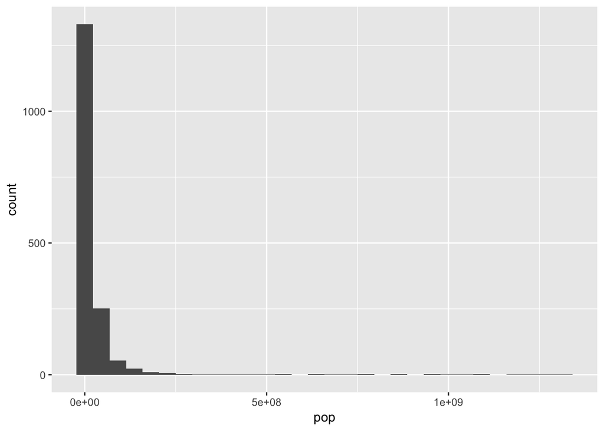

```r
ggplot(test_var, aes(pop)) + geom_histogram()
```

distribution in Africa

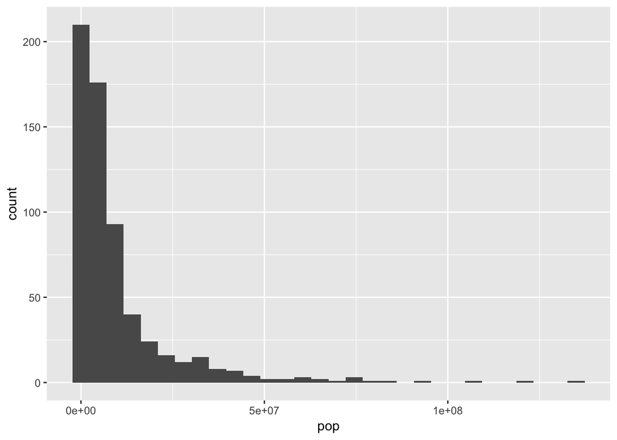

```r
ggplot(Af, aes(pop)) + geom_histogram(bins = 30)
```

distribution in Americas

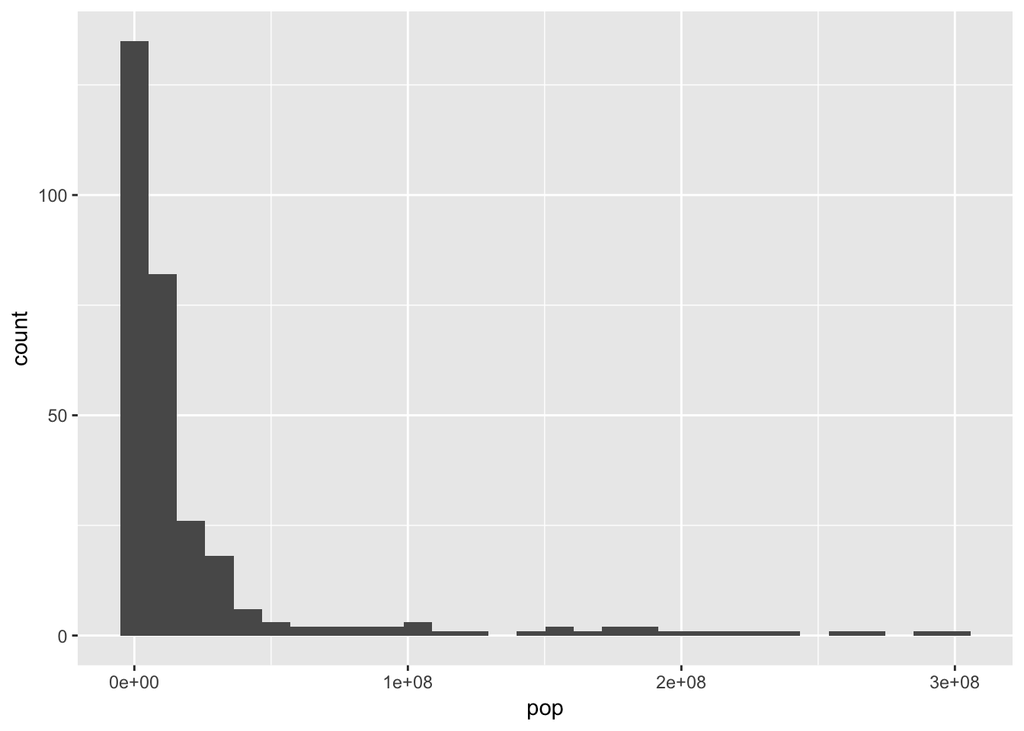

```r
ggplot(Am, aes(pop)) + geom_histogram(bins = 30)
```

distribution in Asia

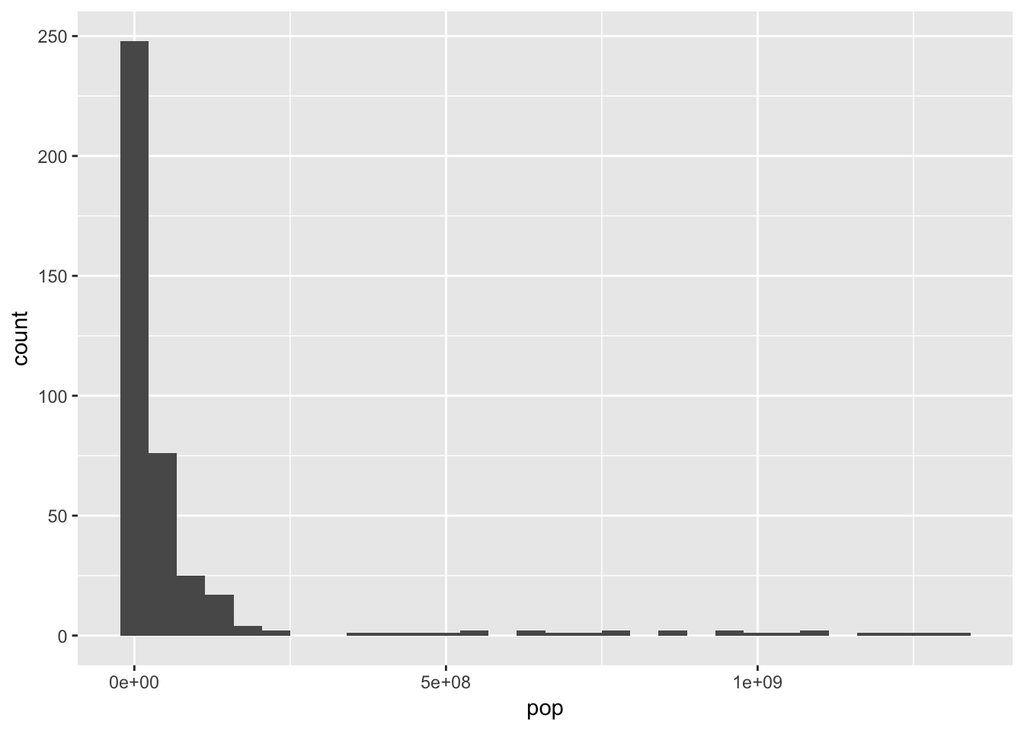

```r
ggplot(As, aes(pop)) + geom_histogram(bins = 30)
```

distribution in Europe

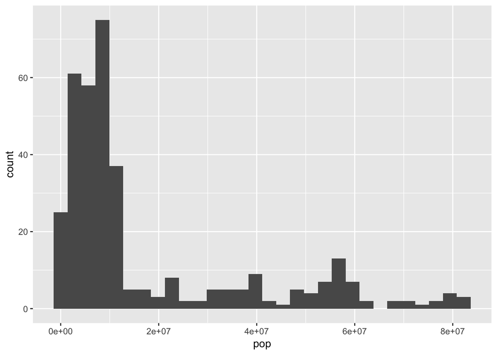

```r
ggplot(Eu, aes(pop)) + geom_histogram(bins = 30)
```

distribution in Oceania

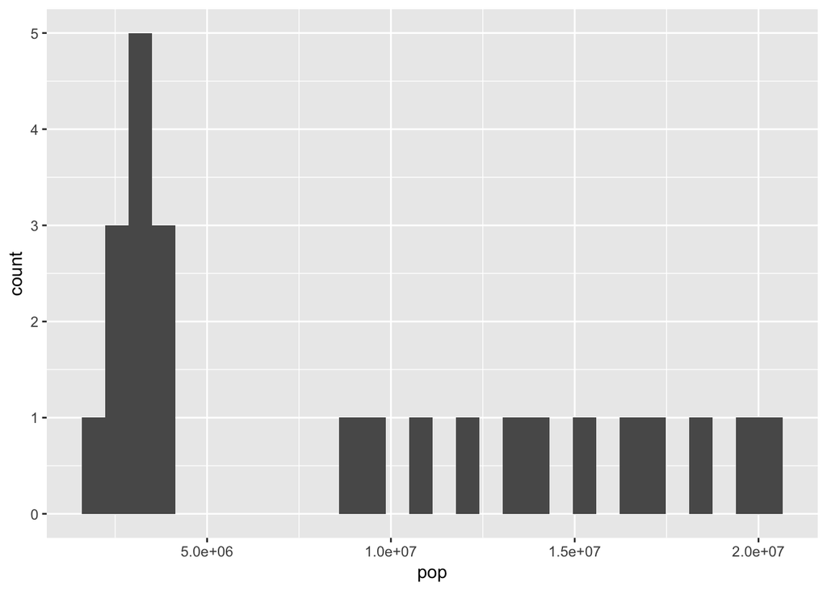

```r
ggplot(Oc, aes(pop)) + geom_histogram(bins = 30)
```

## Explore various plot types

Make a few plots, probably of the same variable you chose to characterize numerically. You can use the plot types we went over in class (cm006) to get an idea of what you’d like to make. Try to explore more than one plot type.

#### 1. A scatterplot of two quantitative variables

the scatter plot of year and pop

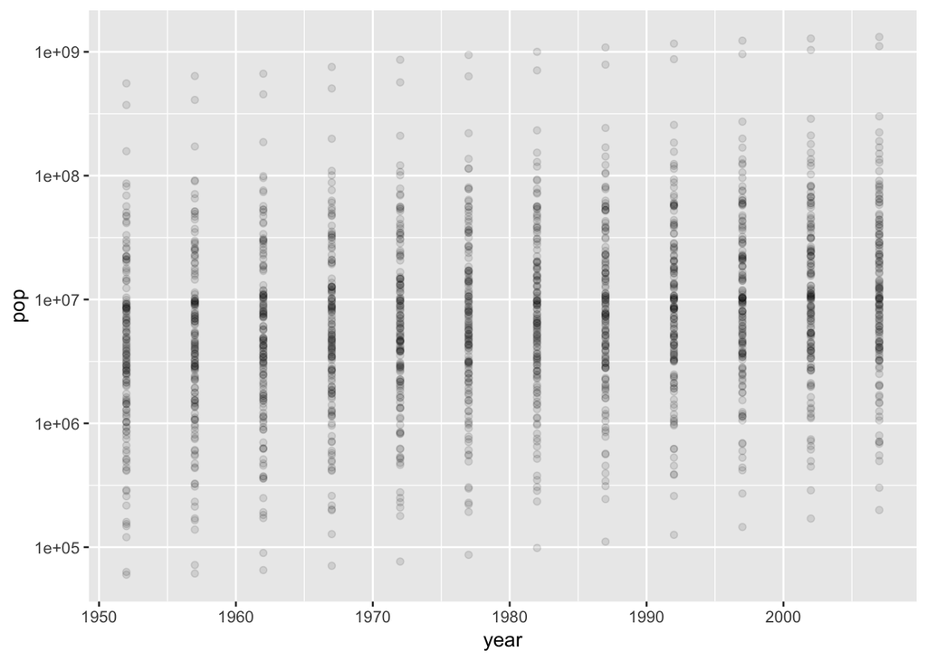

```r
ggplot(gapminder, aes(year, pop)) + scale_y_log10() + geom_point(alpha=0.1)
```

#### 2. A plot of one quantitative variable

the density plot of lifeExp

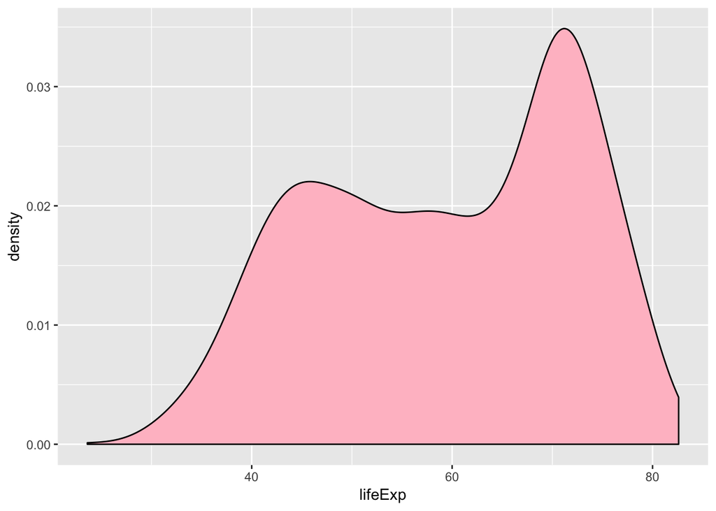

```r
ggplot(gapminder, aes(lifeExp)) + geom_density(fill="pink")
```

#### 3. A plot of one quantitative variable and one categorical

box plot for each continent

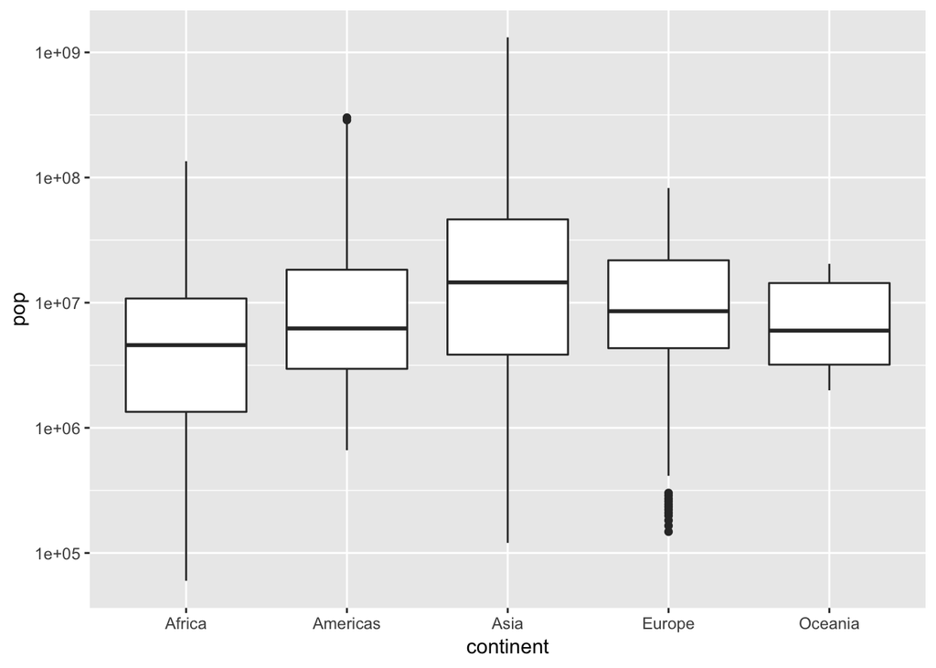

```r
ggplot(test_var, aes(continent, pop)) + scale_y_log10() + geom_boxplot()
```

## Use filter(), select() and %>%

After 1980, the lifeExp in each continent, and build a scatter plot

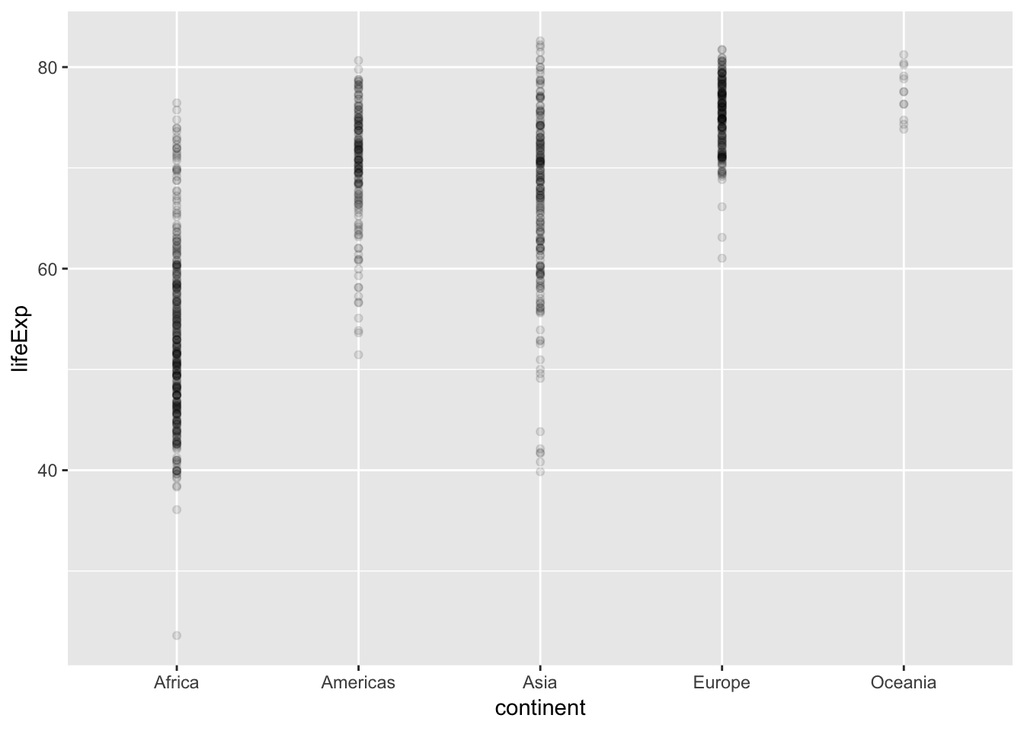

```r
gapminder %>%
  select(continent,lifeExp, year) %>%
  filter(year > 1980) %>%
  ggplot(aes(continent, lifeExp)) + geom_point(alpha=0.1)
```

## But I want to do more!

#### 1. Evaluate this code and describe the result. Presumably the analyst’s intent was to get the data for Rwanda and Afghanistan. Did they succeed? Why or why not? If not, what is the correct way to do this?

```r
filter(gapminder, country == c("Rwanda", "Afghanistan"))
```

```
## # A tibble: 12 x 6
##    country     continent  year lifeExp      pop gdpPercap
##    <fct>       <fct>     <int>   <dbl>    <int>     <dbl>
##  1 Afghanistan Asia       1957    30.3  9240934      821.
##  2 Afghanistan Asia       1967    34.0 11537966      836.
##  3 Afghanistan Asia       1977    38.4 14880372      786.
##  4 Afghanistan Asia       1987    40.8 13867957      852.
##  5 Afghanistan Asia       1997    41.8 22227415      635.
##  6 Afghanistan Asia       2007    43.8 31889923      975.
##  7 Rwanda      Africa     1952    40    2534927      493.
##  8 Rwanda      Africa     1962    43    3051242      597.
##  9 Rwanda      Africa     1972    44.6  3992121      591.
## 10 Rwanda      Africa     1982    46.2  5507565      882.
## 11 Rwanda      Africa     1992    23.6  7290203      737.
## 12 Rwanda      Africa     2002    43.4  7852401      786.
```

They didn’t succeed, because c() creates a vector with “Rwanda” and “Afghanistan”, so it just filters the data with this combination. And the correct way is to use “|” :

```r
filter(gapminder, country=="Rwanda"|country=="Afghanistan")
```

```
## # A tibble: 24 x 6
##    country     continent  year lifeExp      pop gdpPercap
##    <fct>       <fct>     <int>   <dbl>    <int>     <dbl>
##  1 Afghanistan Asia       1952    28.8  8425333      779.
##  2 Afghanistan Asia       1957    30.3  9240934      821.
##  3 Afghanistan Asia       1962    32.0 10267083      853.
##  4 Afghanistan Asia       1967    34.0 11537966      836.
##  5 Afghanistan Asia       1972    36.1 13079460      740.
##  6 Afghanistan Asia       1977    38.4 14880372      786.
##  7 Afghanistan Asia       1982    39.9 12881816      978.
##  8 Afghanistan Asia       1987    40.8 13867957      852.
##  9 Afghanistan Asia       1992    41.7 16317921      649.
## 10 Afghanistan Asia       1997    41.8 22227415      635.
## # ... with 14 more rows
```

#### 2. Present numerical tables in a more attractive form, such as using knitr::kable().Use more of the dplyr functions for operating on a single table.

```r
library(knitr)
library(kableExtra)
```

```r
gapminder[1:10, ] %>%
  mutate(continent = cell_spec(continent, color = "white", bold = T, background = spec_color(1:10, end = 0.9, option = "A", direction = -1))) %>%
  mutate_if(is.numeric, function(x) {
    cell_spec(x, bold = T, color = spec_color(x, end = 0.9))
  }) %>%
  kable(escape = F, align = "c") %>%
  kable_styling(c("striped", "condensed"))
```

| country | continent | year | lifeExp | pop | gdpPercap |
| --- | --- | --- | --- | --- | --- |
| Afghanistan | Asia | 1952 | 28.801 | 8425333 | 779.4453145 |
| Afghanistan | Asia | 1957 | 30.332 | 9240934 | 820.8530296 |
| Afghanistan | Asia | 1962 | 31.997 | 10267083 | 853.10071 |
| Afghanistan | Asia | 1967 | 34.02 | 11537966 | 836.1971382 |
| Afghanistan | Asia | 1972 | 36.088 | 13079460 | 739.9811058 |
| Afghanistan | Asia | 1977 | 38.438 | 14880372 | 786.11336 |
| Afghanistan | Asia | 1982 | 39.854 | 12881816 | 978.0114388 |
| Afghanistan | Asia | 1987 | 40.822 | 13867957 | 852.3959448 |
| Afghanistan | Asia | 1992 | 41.674 | 16317921 | 649.3413952 |
| Afghanistan | Asia | 1997 | 41.763 | 22227415 | 635.341351 |